# 1. (Based on Rice 6.3) Let Xbar be the average of a sample of n independent standard normal RVs.

(a) Determine c such that P(|X| < c) = 0.5. Solve for c as a function of n.

(b) Using only R *norm() functions for the standard normal distribution, compute the exact value of c for n = 5,...100 and visualize as a plot of c vs. n.

(c) If the variance was not known, how would you solve the problem and what additional piece of information would you need to get an exact answer?

(d) If the n RVs are independent and have the same distribution with expectation 0 and variance 1 but the exact distribution is not known, how would you approach the problem?

a) \begin{equation} P(|\bar{X} \leqslant c|) = P(-c \leqslant \bar{X} \leqslant c) = P(\bar{X} \leqslant c) - P(\bar{X} \leqslant -c) \\ = P(\bar{X} \leqslant c) - [1-P(\bar{X} \leqslant c)] = 2P(\bar{X} \leqslant c)-1 = 2F_{\bar{X}}c-1 \\ P(\bar{X} \leqslant c) - 1 = 2\phi(\frac{c-0}{\sqrt{\frac{1}{n}}}) - 1 = 2\phi{\sqrt{n}*c}-1 = .5 \\ 2\phi(\sqrt{n}*c) = 1.5 = \phi(\sqrt{n}*c) = .75 \\ = \sqrt{n}*c = \phi^{-1}(.75) \\ \therefore c = \frac{.674}{\sqrt{n}} \end{equation}

0.588111272540174

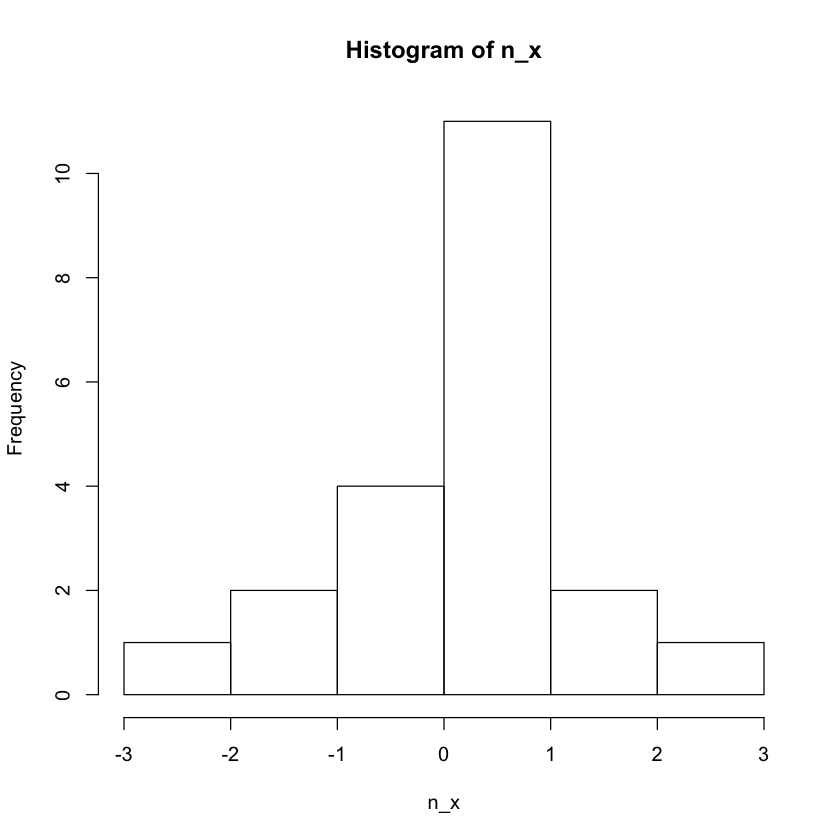

```r
#b
n <- seq(0, 100, by=5) # vector of n values from 0 to 100
n_x <- rnorm(n,mean=0,sd=sqrt(1)) # random normal with n = a random n value from "n"
qnorm(.674, mean = mean(n_x), sd = sd(n_x)) # finding value of c with qnorm
hist(n_x)
```

c) we could solve for varaince with knowing our sample size, values in the set, and our sample mean.

d) I would approach it by using inverse cdf to find the value.

# 2.

a) \begin{equation} Show \; that \; if \; T \sim t_n, \; then \; T^2 \sim F_{1,n} \end{equation}

b) For n=10, demonstrate this equivalence numerically by plotting the kernel density esti- mates for 1000 randomly generated T 2 values and 1000 randomly generated F1,n values.

a) \begin{equation} Let \; X \; be \; T \; and \; let \; Y \; be \; X^2 \\ Y = g(X) = X^2 \;is \; 1-1 \; transformation \; from \; X = [x|-\infty < c < \infty] \\ to \;Y = [y|y>0] \; with \; the \; inverse \; function \; X =g^{-1}(Y) = \sqrt{Y} \; and \; the \; \\ Jacobian \; of \;\frac{dX}{dY} = \frac{1}{2\sqrt{Y}} \\ \therefore f_Y(y) = f_X(g^{-1}(y))|\frac{dx}{dy}| \\ = \frac{\Gamma(\frac{n+1}{2})}{\sqrt{n\pi}\Gamma \frac{n}{2}(\frac{\sqrt{y}^2}{n}+1)^{\frac{n+1}{2}}} * |\frac{1}{2\sqrt{y}}| \\ = \frac{\Gamma((n+1)/2)(1/n)^{1/2}y^{1/2-1}}{\Gamma(1/2)\Gamma(n\2)[y/n+1]^{(n+1)/2}} \;, y>0 \\ this \; is \; pdf \; of \; a \; F(1,n) \; r.v. \end{equation}

```r
#b couldnt get it
```

# 4 Which of the following is a random variable? Justify your answers.

(a) The population mean.

(b) The population size, N.

(c) The sample size, n.

(d) The sample mean.

(e) The variance of the sample mean.

(f) The largest value in the sample.

(g) The population variance.

(h) The estimated variance of the sample mean.

a) Not a random variable because the mean of a distribution is just a number. The value of the pop. mean does not change.

b) Not a random variable, this is a fixed number that defines the underlying pop.

c) Not a random varaible, since this is a number related to the sample, n does not change from sample to sample

d) This is a random varaible because our sample mean will change from sample to sample.

e) Since variance of a sample mean is found using population varaince / n, the population varaince is a fixed value and thus makes it not a random variable.

f) This is a random variable, for our max value changes from sample to sample.

g) Not a random varaible because population varaince is is a number.

h) Since s^2 can change from sample to sample, this is a random variable.

# 5 Two populations are surveyed with simple random sampling. A sample of size n1 is used for population I, which has a population standard deviation of σ1; a sample of size n2 = 3n1 is used for population II, which has a population standard deviation of σ2 = 2σ1.

(a) Ignoring the finite population correction, in which of the two samples would you ex- pect the estimate of the population mean to be more accurate (i.e., smallest variance)? Provide a mathematical justification for your answer.

(b) For what ratio of n2/n1 would the estimates have equivalent accuracy (i.e., equivalent variances)?

a) \begin{equation} V(\bar{X_1}) = \frac{\sigma_1^2}{n_1} \\ V(\bar{X_2}) = \frac{\sigma_2^2}{n_2} \end{equation} I would expect the population mean to be more accurate in our first sample due to a better proportion of std to the width of a confidence interval.

b) we need 9 times more data (n) to make second proportional to first sample.

# 6 (Based on Rice 7.10) True or false (and state why): If a sample from a population is large, a histogram of the values in the sample will be appropriately normal, even if the population is not normal? Verify your answer via simulation.

False, proof by contradiction, a sample from a uniform population will always be uniform. Regardles of your n/N, your sample will always be a uniform distribution regardless of how big or small n is.

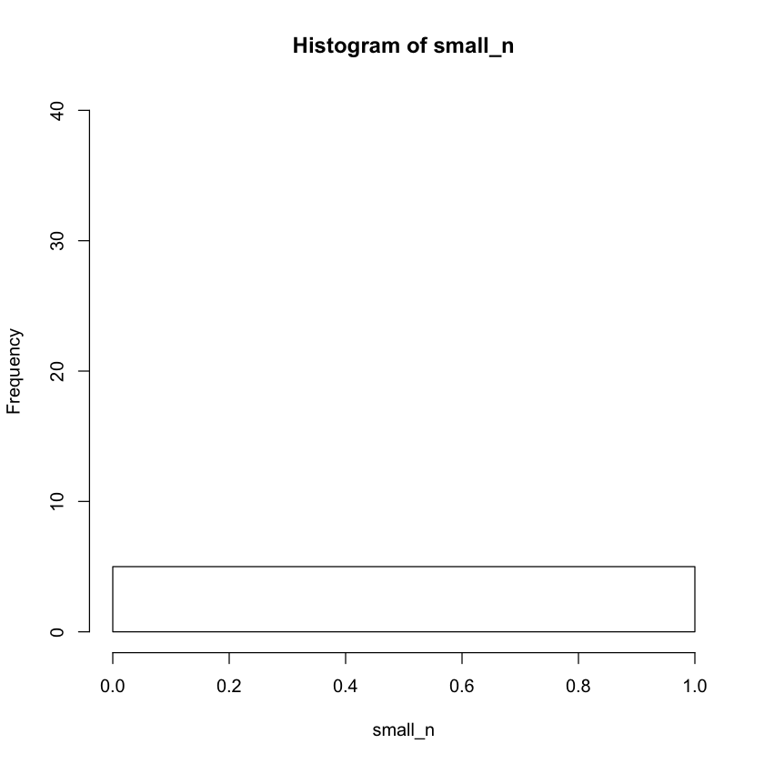

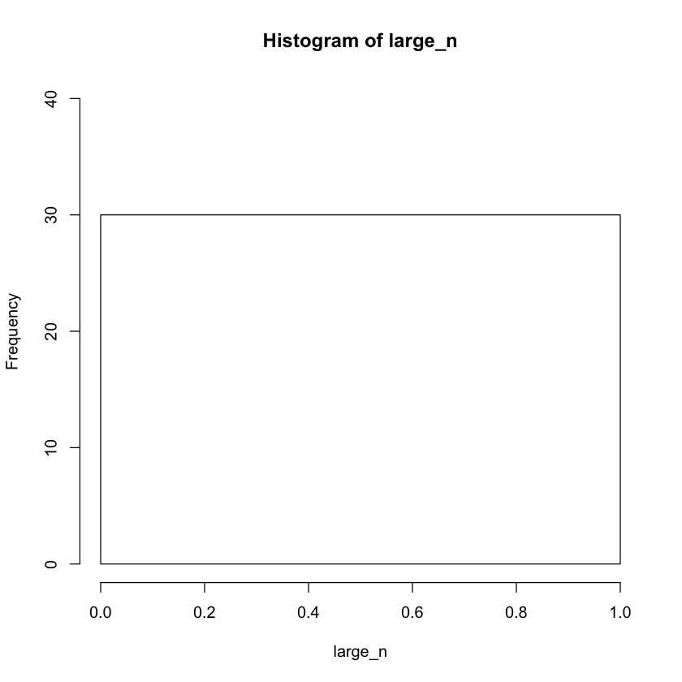

```r
# computational proof by contradiction
a<-c(1,1,1,1,1,1,1,1,1,1,1,1,1,1,1,1,1,1,1,1,1,1,1,1,1,1,1,1,1,1,1,1,1,1,1,1,1,1,1,1,1,1,1,1,1,1,1,1,1,1,1,1,1,1,1,1,1)
small_n <- sample(a, 5)
h <- hist(small_n,ylim=c(0,40))
large_n <- sample(a,30)
h1 <- hist(large_n,ylim=c(0,40))
```

# 7 (Based on Rice 7.16) True or false? Justify your answers.

(a) The center of a 95% confidence interval for the population mean is a random variable.

(b) A 95% confidence interval for μ contains the sample mean with probability 0.95.

(c) A 95% confidence interval contains 95% of the population.

a) This is true due to the nature of the formula. Since the formula includes a sample mean, which is random due to the value beeing prone to change from sample to sample. In addition, this is also true for a sample standard deviation. Thus, since these two metrics are random and confidence intervals are contructed with these parametes, the center and spread of a confidence interval will change from sample to sample.

b) This is false because a 95% confidence interval for pop. mean will contain the population mean with certainty 1, not .95.

c) This assumption is false, a 95% confidence interval refers to 95/100 times that the interval from samples will capture the true mean, not the population. It does not need to capture the set fraction of the population.